# Efficient Estimation of Bid-Ask Spreads from Open, High, Low, and Close Prices

This vignette illustrates how to estimate bid-ask spreads from open, high, low, and close prices using the efficient estimator described in Ardia, Guidotti, & Kroencke (JFE, 2024): https://doi.org/10.1016/j.jfineco.2024.103916.

```r
library(bidask)
```

The function `edge` computes a single bid-ask spread estimate from vectors of open, high, low, and close prices. The functions `edge_rolling` and `edge_expanding` are optimized for fast calculations over rolling and expanding windows, respectively. The function `spread` provides additional functionalities for `xts` objects and implements additional estimators. For all functions, an output value of 0.01 corresponds to a spread estimate of 1%.

## Functions `edge`, `edge_rolling`, `edge_expanding`

These functions can be easily used with tidy data. For instance, download daily prices for Bitcoin and Ethereum using the crypto2 package:

```r
library(dplyr)
library(crypto2)
df <- crypto_list(only_active=TRUE) %>%
  filter(symbol %in% c("BTC", "ETH")) %>%
  crypto_history(start_date = "20200101", end_date = "20221231")
```

```r
head(df)
```

```
#> # A tibble: 6 × 17
#>      id slug    name    symbol timestamp           ref_cur_id ref_cur_name
#>   <int> <chr>   <chr>   <chr>  <dttm>              <chr>      <chr>
#> 1     1 bitcoin Bitcoin BTC    2020-01-01 23:59:59 2781       USD
#> 2     1 bitcoin Bitcoin BTC    2020-01-02 23:59:59 2781       USD
#> 3     1 bitcoin Bitcoin BTC    2020-01-03 23:59:59 2781       USD
#> 4     1 bitcoin Bitcoin BTC    2020-01-04 23:59:59 2781       USD
#> 5     1 bitcoin Bitcoin BTC    2020-01-05 23:59:59 2781       USD
#> 6     1 bitcoin Bitcoin BTC    2020-01-06 23:59:59 2781       USD
#> # ℹ 10 more variables: time_open <dttm>, time_close <dttm>, time_high <dttm>,
#> #   time_low <dttm>, open <dbl>, high <dbl>, low <dbl>, close <dbl>,
#> #   volume <dbl>, market_cap <dbl>
```

Estimate the spread for each coin in each year:

```r
df %>%
  mutate(yyyy = format(timestamp, "%Y")) %>%
  group_by(symbol, yyyy) %>%
  arrange(timestamp) %>%
  summarise("EDGE" = edge(open, high, low, close))
```

[output not shown]

Estimate the spread using a rolling window of 30 days for each coin and plot the results:

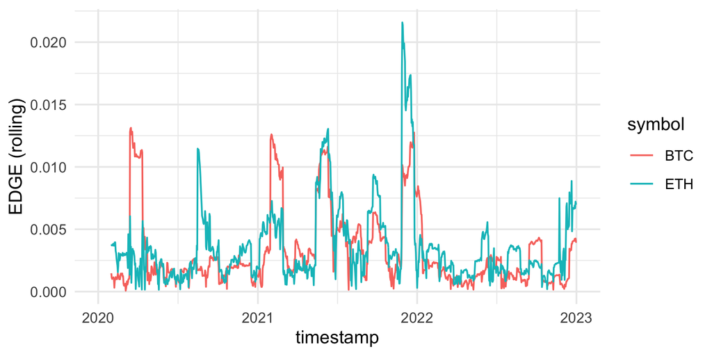

```r
library(ggplot2)
df %>%
  group_by(symbol) %>%
  arrange(timestamp) %>%
  mutate("EDGE (rolling)" = edge_rolling(open, high, low, close, width = 30)) %>%
  ggplot(aes(x = timestamp, y = `EDGE (rolling)`, color = symbol)) +
  geom_line() +
  theme_minimal()
```

Estimate the spread using an expanding window for each coin and plot the results:

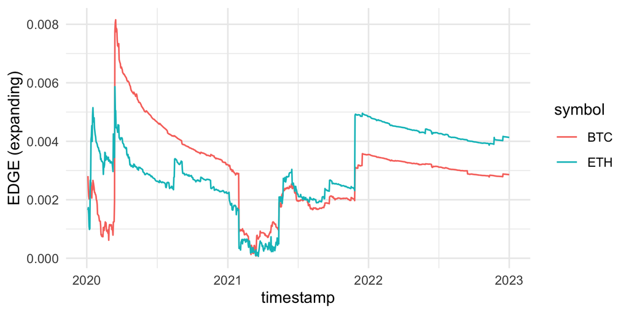

```r
df %>%
  group_by(symbol) %>%
  arrange(timestamp) %>%
  mutate("EDGE (expanding)" = edge_expanding(open, high, low, close)) %>%
  ggplot(aes(x = timestamp, y = `EDGE (expanding)`, color = symbol)) +
  geom_line() +
  theme_minimal()
```

Notice that, generally, using intraday data (instead of daily) improves the estimation accuracy, especially when the spread is expected to be small (see example below).

## Function `spread`

The function `spread()` provides additional functionalities for xts objects and implements additional estimators. For instance, download daily data for Microsoft (MSFT) using the quantmod package which returns an `xts` object:

```r
library(quantmod)
x <- try(getSymbols("MSFT", auto.assign = FALSE, start = "2019-01-01", end = "2022-12-31"), silent = TRUE)
if("try-error" %in% class(x)){
  print("Error in getSymbols; using syntentic data instead")
  x <- sim(5000, units = "day")
}
```

```r
class(x)
```

```
#> [1] "xts" "zoo"
```

```r
head(x)
```

```
#>            MSFT.Open MSFT.High MSFT.Low MSFT.Close MSFT.Volume MSFT.Adjusted
#> 2007-01-03     29.91     30.25    29.40      29.86    76935100      21.16159
#> 2007-01-04     29.70     29.97    29.44      29.81    45774500      21.12617
#> 2007-01-05     29.63     29.75    29.45      29.64    44607200      21.00569
#> 2007-01-08     29.65     30.10    29.53      29.93    50220200      21.21120
#> 2007-01-09     30.00     30.18    29.73      29.96    44636600      21.23247
#> 2007-01-10     29.80     29.89    29.43      29.66    55017400      21.01986
```

Estimate the spread with:

```r
spread(x)
```

```
#>                   EDGE
#> 2025-10-10 0.005487963
```

or, equivalently:

```r
edge(open = x[,1], high = x[,2], low = x[,3], close = x[,4])
```

```
#> [1] 0.005487963
```

Estimate the spread for each month and plot the estimates:

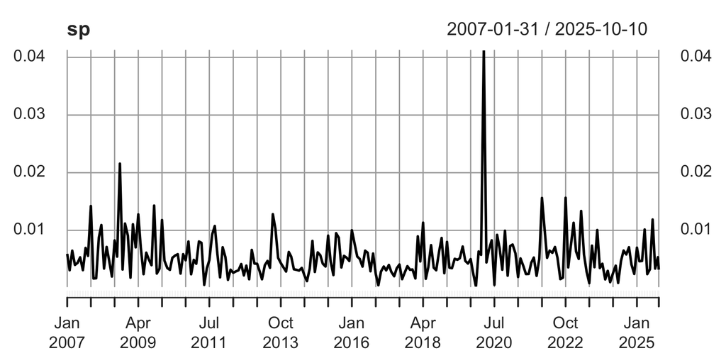

```r
sp <- spread(x, width = endpoints(x, on = "months"))
plot(sp)
```

Estimate the spread using a rolling window of 21 obervations:

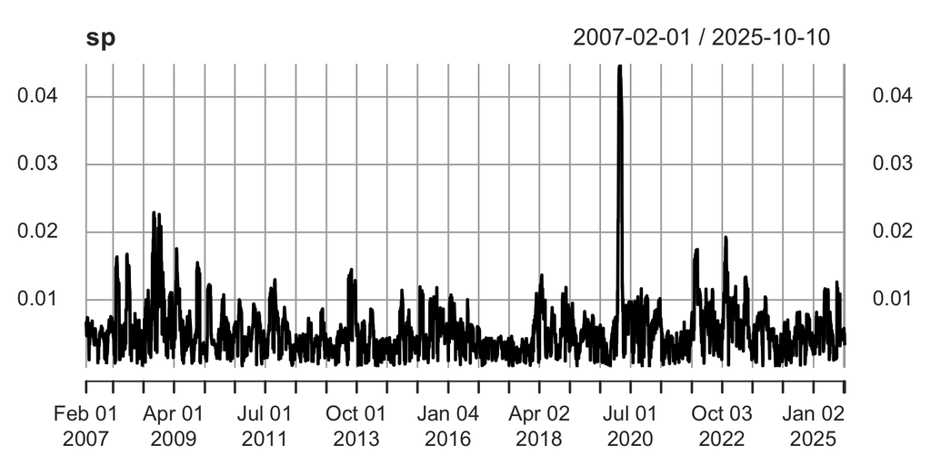

```r
sp <- spread(x, width = 21)
plot(sp)
```

To illustrate higher-frequency estimates, download intraday data from Alpha Vantage. You must register with Alpha Vantage in order to download their data, but the one-time registration is fast and free. Register at https://www.alphavantage.co/ to receive your key. You can set the API key globally as follows:

```r
setDefaults(getSymbols.av, api.key = "<API-KEY>")
```

Download minute data for Microsoft:

```r
x <- getSymbols(
  Symbols = "MSFT",
  auto.assign = FALSE,
  src = "av",
  periodicity = "intraday",
  interval = "1min",
  output.size = "full")
```

Keep only prices during regular market hours:

```r
x <- x["T09:30/T16:00"]
head(x)
```

```
#>                     MSFT.Open MSFT.High MSFT.Low MSFT.Close MSFT.Volume
#> 2023-08-17 09:30:00   320.540   321.870  320.405     321.75      364230
#> 2023-08-17 09:31:00   321.780   321.781  320.890     321.04       66948
#> 2023-08-17 09:32:00   321.080   321.330  320.805     321.16       61487
#> 2023-08-17 09:33:00   321.220   321.220  320.450     320.63       51775
#> 2023-08-17 09:34:00   320.625   320.920  320.480     320.60       57119
#> 2023-08-17 09:35:00   320.570   320.860  320.455     320.71       90454
```

Estimate the spread for each day and plot the estimates:

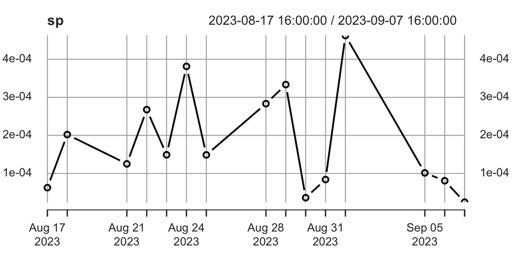

```r
sp <- spread(x, width = endpoints(x, on = "day"))
plot(sp, type = "b")
```

Use multiple estimators and plot the estimates:

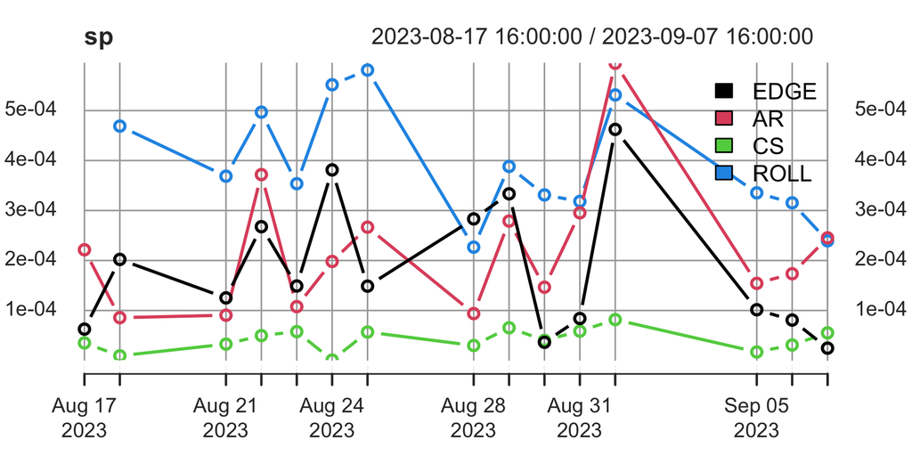

```r
sp <- spread(x, width = endpoints(x, on = "day"), method = c("EDGE", "AR", "CS", "ROLL"))
plot(sp, type = "b", legend.loc = "topright")
```

## GitHub

If you find this package useful, please [star the repo](https://github.com/eguidotti/bidask)! The repository also contains implementations for Python, C++, MATLAB, and more; as well as open data containing bid-ask spread estimates for crypto pairs in Binance and for U.S. stocks in CRSP.

## Cite as

> Ardia, D., Guidotti, E., Kroencke, T.A. (2024). Efficient Estimation of Bid-Ask Spreads from Open, High, Low, and Close Prices. *Journal of Financial Economics*, 161, 103916. [doi: 10.1016/j.jfineco.2024.103916](https://doi.org/10.1016/j.jfineco.2024.103916)

A BibTex entry for LaTeX users is:

```
@article{edge,
  title = {Efficient estimation of bid–ask spreads from open, high, low, and close prices},
  journal = {Journal of Financial Economics},
  volume = {161},
  pages = {103916},
  year = {2024},
  doi = {https://doi.org/10.1016/j.jfineco.2024.103916},
  author = {David Ardia and Emanuele Guidotti and Tim A. Kroencke},
}
```